# Modeling car Insurance accidents and cost of accidents

Author

Darwhin Gomez

## Modeling for car Insurance

Car insurance provides financial protection in cases of property damage or personal injury resulting from automobile accidents. Insurers must estimate two key outcomes for each policyholder:

1. The probability that the driver will be involved in a crash, and
2. The expected financial cost of that crash, if one occurs.

Accurate predictions of both components are essential for pricing policies, managing risk, and ensuring the financial stability of the insurer. From a modeling perspective, this naturally leads to a two-part predictive task: a binary classification problem (crash vs. no crash) and a continuous regression problem (claim cost conditional on a crash).

To address these questions, we apply supervised machine learning techniques—specifically binary logistic regression to model crash probability, and multiple linear regression to estimate crash cost. Both modeling approaches are appropriate given the structured, tabular nature of the data and the interpretability requirements common in insurance analytics.

The provided training data consist of 8,161 observations and 26 variables, including demographic characteristics, vehicle attributes, prior claims history, driving record, and socioeconomic indicators. The evaluation dataset includes an additional 2,141 records for which model predictions must be generated.

### Methods

This study follows a structured end-to-end modeling workflow typical in actuarial data mining:

Together, these results provide a data-driven assessment of driver risk and expected financial exposure for the insurer.

## Data exploration

```r
train_missing_rows <- train %>%
  filter(if_any(everything(), is.na))

train_missing_rows
```

```
# A tibble: 2,116 × 26
   INDEX TARGET_FLAG TARGET_AMT KIDSDRIV   AGE HOMEKIDS   YOJ INCOME   PARENT1
   <dbl>       <dbl>      <dbl>    <dbl> <dbl>    <dbl> <dbl> <chr>    <chr>
 1     5           0          0        0    51        0    14 <NA>     No
 2     6           0          0        0    50        0    NA $114,986 No
 3     8           0          0        0    54        0    NA $18,755  No
 4    11           1       4021        1    37        2    NA $107,961 No
 5    17           1       1267        0    53        0    11 $130,795 No
 6    26           1       3627        0    43        0    13 $37,214  No
 7    36           0          0        0    40        2     0 <NA>     No
 8    41           0          0        0    41        0     7 $92,842  No
 9    46           0          0        0    43        2    17 $145,353 No
10    55           0          0        0    47        0     8 $18,444  No
# ℹ 2,106 more rows
# ℹ 17 more variables: HOME_VAL <chr>, MSTATUS <chr>, SEX <chr>,
#   EDUCATION <chr>, JOB <chr>, TRAVTIME <dbl>, CAR_USE <chr>, BLUEBOOK <chr>,
#   TIF <dbl>, CAR_TYPE <chr>, RED_CAR <chr>, OLDCLAIM <chr>, CLM_FREQ <dbl>,
#   REVOKED <chr>, MVR_PTS <dbl>, CAR_AGE <dbl>, URBANICITY <chr>
```

```r
skim(train)
```

Data summary

| Name | train |
| --- | --- |
| Number of rows | 8161 |
| Number of columns | 26 |
| _______________________ |  |
| Column type frequency: |  |
| character | 10 |
| numeric | 16 |
| ________________________ |  |
| Group variables | None |

**Variable type: character**

| skim_variable | n_missing | complete_rate | min | max | empty | n_unique | whitespace |
| --- | --- | --- | --- | --- | --- | --- | --- |
| PARENT1 | 0 | 1.00 | 2 | 3 | 0 | 2 | 0 |
| MSTATUS | 0 | 1.00 | 3 | 4 | 0 | 2 | 0 |
| SEX | 0 | 1.00 | 1 | 3 | 0 | 2 | 0 |
| EDUCATION | 0 | 1.00 | 3 | 13 | 0 | 5 | 0 |
| JOB | 526 | 0.94 | 6 | 13 | 0 | 8 | 0 |
| CAR_USE | 0 | 1.00 | 7 | 10 | 0 | 2 | 0 |
| CAR_TYPE | 0 | 1.00 | 3 | 11 | 0 | 6 | 0 |
| RED_CAR | 0 | 1.00 | 2 | 3 | 0 | 2 | 0 |
| REVOKED | 0 | 1.00 | 2 | 3 | 0 | 2 | 0 |
| URBANICITY | 0 | 1.00 | 19 | 21 | 0 | 2 | 0 |

**Variable type: numeric**

| skim_variable | n_missing | complete_rate | mean | sd | p0 | p25 | p50 | p75 | p100 | hist |
| --- | --- | --- | --- | --- | --- | --- | --- | --- | --- | --- |
| INDEX | 0 | 1.00 | 5151.87 | 2978.89 | 1 | 2559 | 5133 | 7745 | 10302.0 | ▇▇▇▇▇ |
| TARGET_FLAG | 0 | 1.00 | 0.26 | 0.44 | 0 | 0 | 0 | 1 | 1.0 | ▇▁▁▁▃ |
| TARGET_AMT | 0 | 1.00 | 1504.32 | 4704.03 | 0 | 0 | 0 | 1036 | 107586.1 | ▇▁▁▁▁ |
| KIDSDRIV | 0 | 1.00 | 0.17 | 0.51 | 0 | 0 | 0 | 0 | 4.0 | ▇▁▁▁▁ |
| AGE | 6 | 1.00 | 44.79 | 8.63 | 16 | 39 | 45 | 51 | 81.0 | ▁▆▇▂▁ |
| HOMEKIDS | 0 | 1.00 | 0.72 | 1.12 | 0 | 0 | 0 | 1 | 5.0 | ▇▂▁▁▁ |
| YOJ | 454 | 0.94 | 10.50 | 4.09 | 0 | 9 | 11 | 13 | 23.0 | ▂▃▇▃▁ |
| INCOME | 445 | 0.95 | 61898.09 | 47572.68 | 0 | 28097 | 54028 | 85986 | 367030.0 | ▇▃▁▁▁ |
| HOME_VAL | 464 | 0.94 | 154867.29 | 129123.77 | 0 | 0 | 161160 | 238724 | 885282.0 | ▇▆▁▁▁ |
| TRAVTIME | 0 | 1.00 | 33.49 | 15.91 | 5 | 22 | 33 | 44 | 142.0 | ▇▇▁▁▁ |
| BLUEBOOK | 0 | 1.00 | 15709.90 | 8419.73 | 1500 | 9280 | 14440 | 20850 | 69740.0 | ▇▆▁▁▁ |
| TIF | 0 | 1.00 | 5.35 | 4.15 | 1 | 1 | 4 | 7 | 25.0 | ▇▆▁▁▁ |
| OLDCLAIM | 0 | 1.00 | 4037.08 | 8777.14 | 0 | 0 | 0 | 4636 | 57037.0 | ▇▁▁▁▁ |
| CLM_FREQ | 0 | 1.00 | 0.80 | 1.16 | 0 | 0 | 0 | 2 | 5.0 | ▇▂▁▁▁ |
| MVR_PTS | 0 | 1.00 | 1.70 | 2.15 | 0 | 0 | 1 | 3 | 13.0 | ▇▂▁▁▁ |
| CAR_AGE | 510 | 0.94 | 8.33 | 5.70 | -3 | 1 | 8 | 12 | 28.0 | ▆▇▇▃▁ |

```r
skim(eval)
```

Data summary

| Name | eval |
| --- | --- |
| Number of rows | 2141 |
| Number of columns | 26 |
| _______________________ |  |
| Column type frequency: |  |
| character | 10 |
| logical | 1 |
| numeric | 15 |
| ________________________ |  |
| Group variables | None |

**Variable type: character**

| skim_variable | n_missing | complete_rate | min | max | empty | n_unique | whitespace |
| --- | --- | --- | --- | --- | --- | --- | --- |
| PARENT1 | 0 | 1.00 | 2 | 3 | 0 | 2 | 0 |
| MSTATUS | 0 | 1.00 | 3 | 4 | 0 | 2 | 0 |
| SEX | 0 | 1.00 | 1 | 3 | 0 | 2 | 0 |
| EDUCATION | 0 | 1.00 | 3 | 13 | 0 | 5 | 0 |
| JOB | 139 | 0.94 | 6 | 13 | 0 | 8 | 0 |
| CAR_USE | 0 | 1.00 | 7 | 10 | 0 | 2 | 0 |
| CAR_TYPE | 0 | 1.00 | 3 | 11 | 0 | 6 | 0 |
| RED_CAR | 0 | 1.00 | 2 | 3 | 0 | 2 | 0 |
| REVOKED | 0 | 1.00 | 2 | 3 | 0 | 2 | 0 |
| URBANICITY | 0 | 1.00 | 19 | 21 | 0 | 2 | 0 |

**Variable type: logical**

| skim_variable | n_missing | complete_rate | mean | count |
| --- | --- | --- | --- | --- |
| TARGET_FLAG | 2141 | 0 | NaN | : |

**Variable type: numeric**

| skim_variable | n_missing | complete_rate | mean | sd | p0 | p25 | p50 | p75 | p100 | hist |
| --- | --- | --- | --- | --- | --- | --- | --- | --- | --- | --- |
| INDEX | 0 | 1.00 | 5150.10 | 2956.33 | 3 | 2632.00 | 5224 | 7669.00 | 10300 | ▇▇▇▇▇ |
| TARGET_AMT | 2141 | 0.00 | NaN | NA | NA | NA | NA | NA | NA |  |
| KIDSDRIV | 0 | 1.00 | 0.16 | 0.49 | 0 | 0.00 | 0 | 0.00 | 3 | ▇▁▁▁▁ |
| AGE | 1 | 1.00 | 45.02 | 8.53 | 17 | 39.00 | 45 | 51.00 | 73 | ▁▅▇▅▁ |
| HOMEKIDS | 0 | 1.00 | 0.72 | 1.12 | 0 | 0.00 | 0 | 1.00 | 5 | ▇▂▁▁▁ |
| YOJ | 94 | 0.96 | 10.38 | 4.17 | 0 | 9.00 | 11 | 13.00 | 19 | ▂▂▆▇▁ |
| INCOME | 125 | 0.94 | 60324.27 | 47003.42 | 0 | 25817.75 | 51778 | 86278.25 | 291182 | ▇▅▁▁▁ |
| HOME_VAL | 111 | 0.95 | 153217.67 | 129456.87 | 0 | 0.00 | 158840 | 236651.50 | 669271 | ▇▇▃▁▁ |
| TRAVTIME | 0 | 1.00 | 33.15 | 15.72 | 5 | 22.00 | 33 | 43.00 | 105 | ▆▇▃▁▁ |
| BLUEBOOK | 0 | 1.00 | 15469.43 | 8462.37 | 1500 | 8870.00 | 14170 | 21050.00 | 49940 | ▇▇▅▁▁ |
| TIF | 0 | 1.00 | 5.24 | 3.97 | 1 | 1.00 | 4 | 7.00 | 25 | ▇▆▁▁▁ |
| OLDCLAIM | 0 | 1.00 | 4022.17 | 8565.38 | 0 | 0.00 | 0 | 4718.00 | 54399 | ▇▁▁▁▁ |
| CLM_FREQ | 0 | 1.00 | 0.81 | 1.14 | 0 | 0.00 | 0 | 2.00 | 5 | ▇▂▁▁▁ |
| MVR_PTS | 0 | 1.00 | 1.77 | 2.20 | 0 | 0.00 | 1 | 3.00 | 12 | ▇▂▁▁▁ |
| CAR_AGE | 129 | 0.94 | 8.18 | 5.77 | 0 | 1.00 | 8 | 12.00 | 26 | ▇▇▆▂▁ |

```
 [1] "INDEX"       "TARGET_FLAG" "TARGET_AMT"  "KIDSDRIV"    "AGE"
 [6] "HOMEKIDS"    "YOJ"         "INCOME"      "HOME_VAL"    "TRAVTIME"
[11] "BLUEBOOK"    "TIF"         "OLDCLAIM"    "CLM_FREQ"    "MVR_PTS"
[16] "CAR_AGE"
```

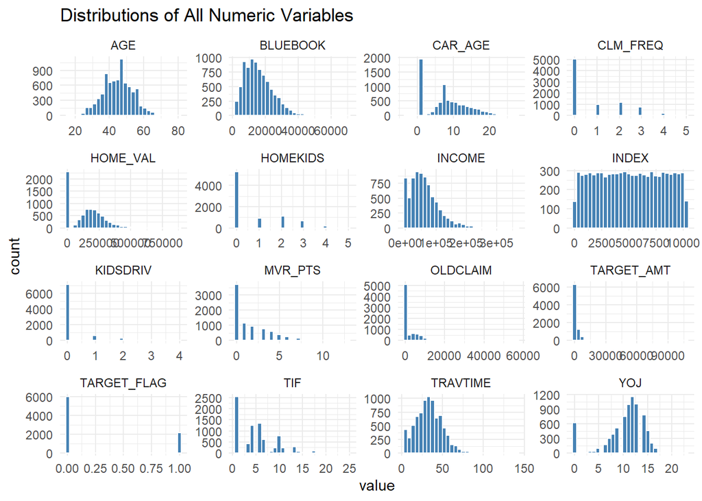

## Data manipulation

### Missing Data

- Job- could be missing for any number of reason, but we will keep this under a new label ” unspecified”, 526 cases in train
- Car age- this is peculiar since car model years is a primary data point for insurance, could it be that these are really new cars, or really old cars, 510 cases in train
- Age - Small number of cases - 6 cases in train. We can do a mean impute here
- Home Value- This could represent that the person does not own a home which would be 0,464 cases
- YOJ - years on job lets see if this connected to people whom do have a job specified, 454 case.
- Income - Income if there is no job listed could make sense to have zero. 445 cases in train.

During data preparation, I observed that many individuals with missing income also had commercial-use vehicles and job category recoded as “SelfEmployed.”

Because self-employed drivers with commercial auto policies likely report income similarly, I imputed their missing `INCOME` values using the median income of all commercial-use customers:

```
57892
```

This preserves domain logic and stabilizes the logistic regression model.

We also imputed missing income for private use cases with the median of cases labeled private :

```
51110
```

Missing values were addressed using domain-appropriate logic.

Income was imputed using median values segmented by vehicle use (commercial vs. private) and adjusted for self-employed individuals. Home values were imputed to zero, YOJ was imputed to zero due to its distribution and realistic interpretation, and CAR_AGE was cleaned by setting negative values to zero and imputing the remaining values using the mean. Job missingness was recoded to “Unspecified,” and records with commercial vehicle use and unspecified job type were reassigned to “SelfEmployed.” All categorical variables were cleaned by removing “z_” prefixes and refactoring levels. Rows missing AGE were removed. After transformation, the dataset contains no problematic missingness and is suitable for modeling.

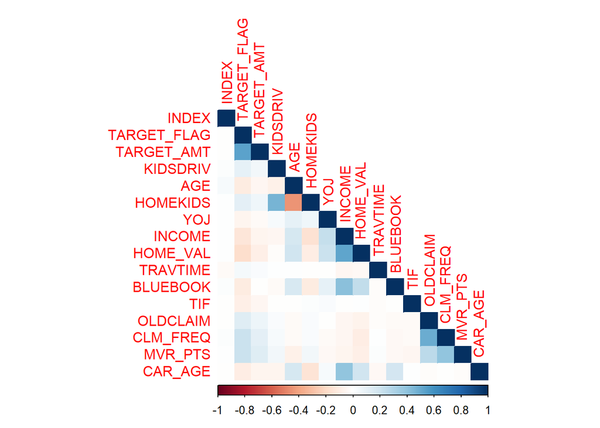

The correlation matrix revealed several meaningful relationships between numeric predictors and the likelihood of being involved in an accident (`TARGET_FLAG`). Variables related to household composition showed notable correlations: having children (`HOMEKIDS`) and especially having children of driving age (`KIDSDRIV`) were positively associated with crash risk. Behavioral and driving-history measures were also strong indicators. Prior claims history (`OLDCLAIM`), claim frequency (`CLM_FREQ`), and accumulated motor vehicle record points (`MVR_PTS`) all demonstrated positive correlations with accident involvement, consistent with actuarial expectations that past behavior is predictive of future risk. Additionally, longer commute distances (`TRAVTIME`) exhibited a mild but meaningful correlation with higher crash probability, reflecting increased road exposure. Overall, the correlation structure supports the inclusion of these variables in the logistic regression model, both for predictive strength and domain relevance.

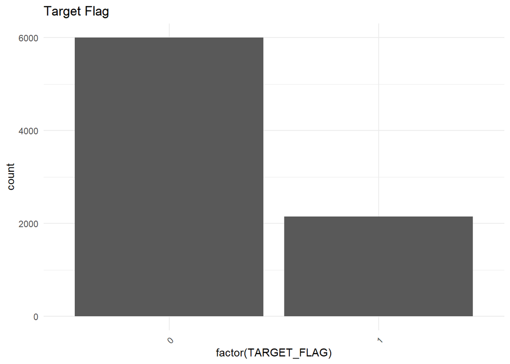

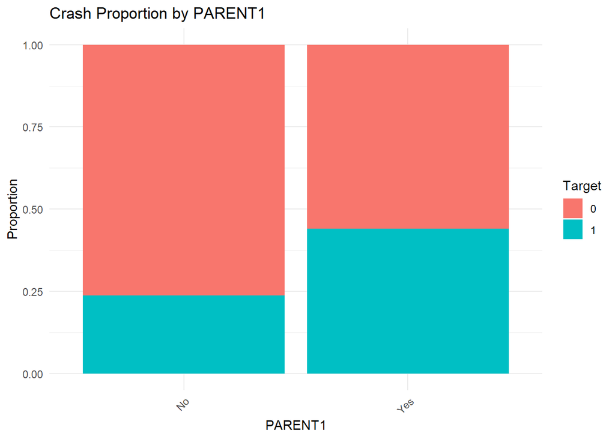

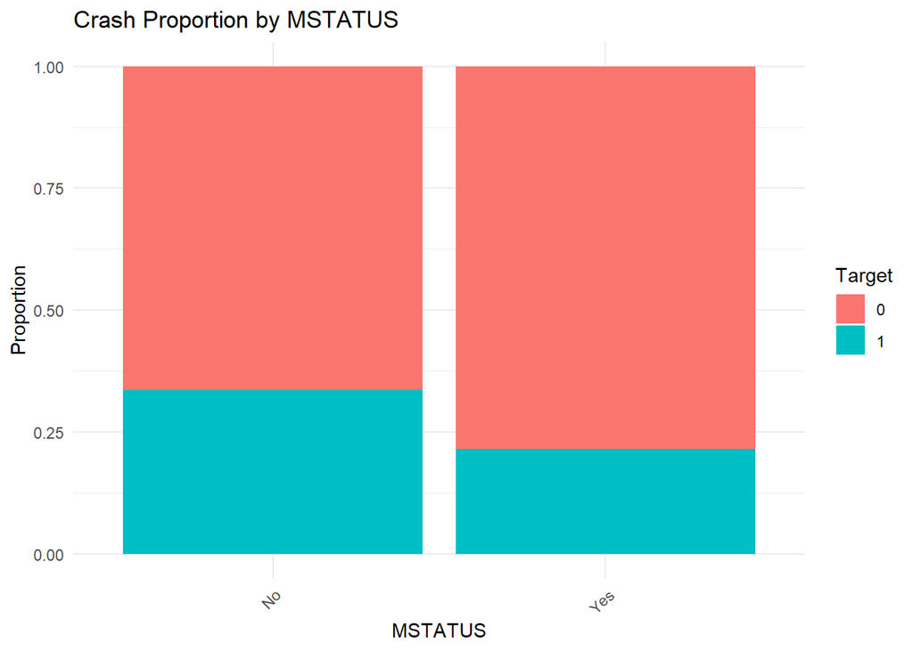

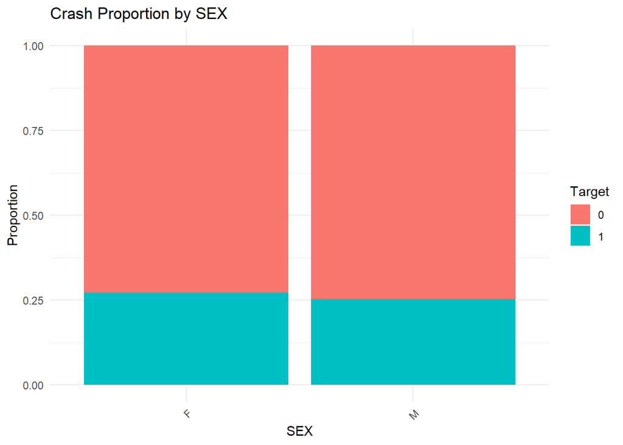

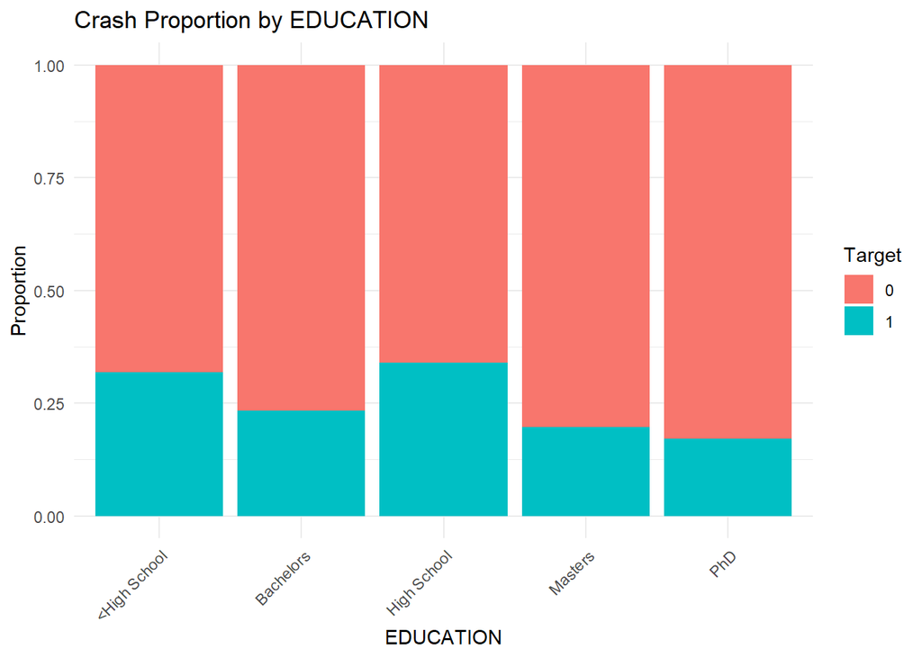

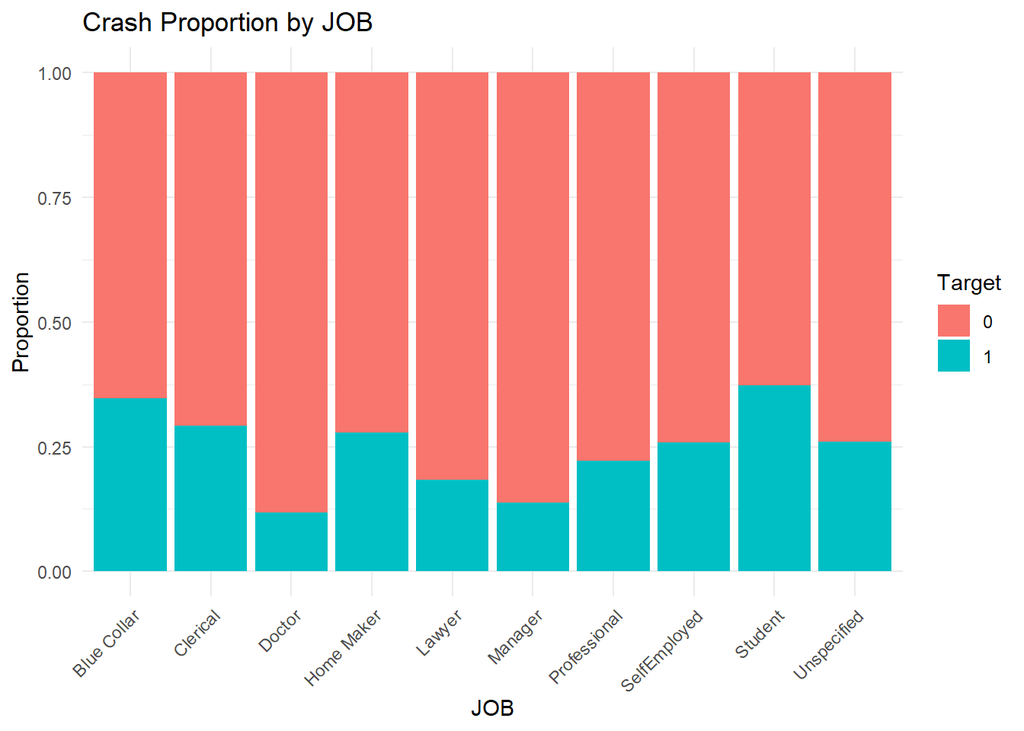

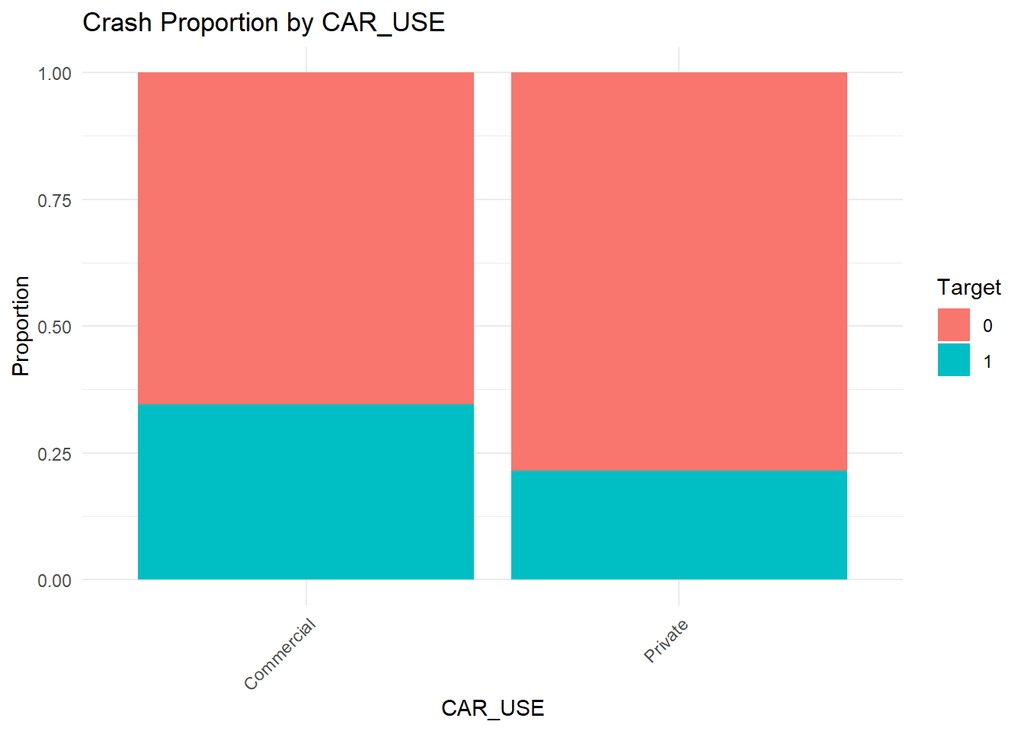

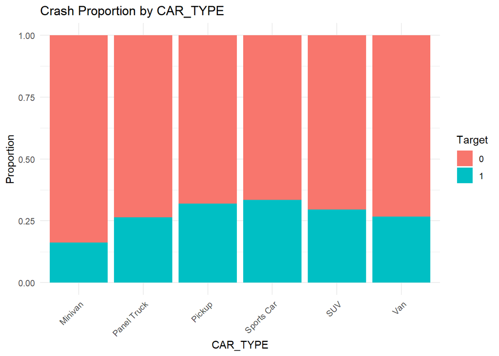

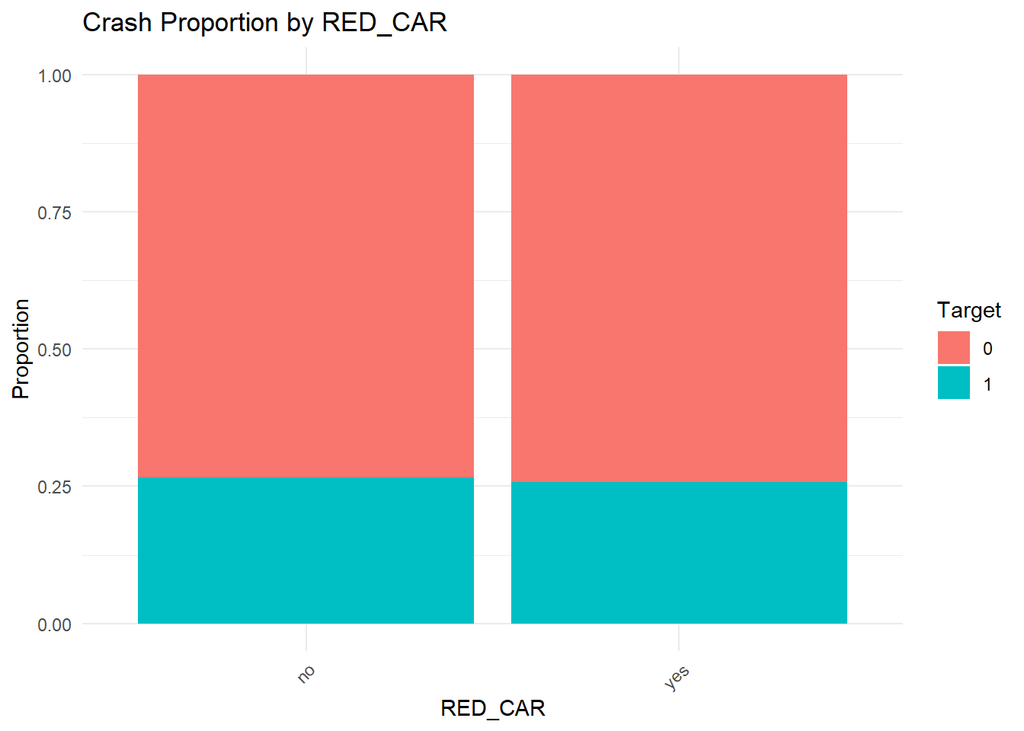

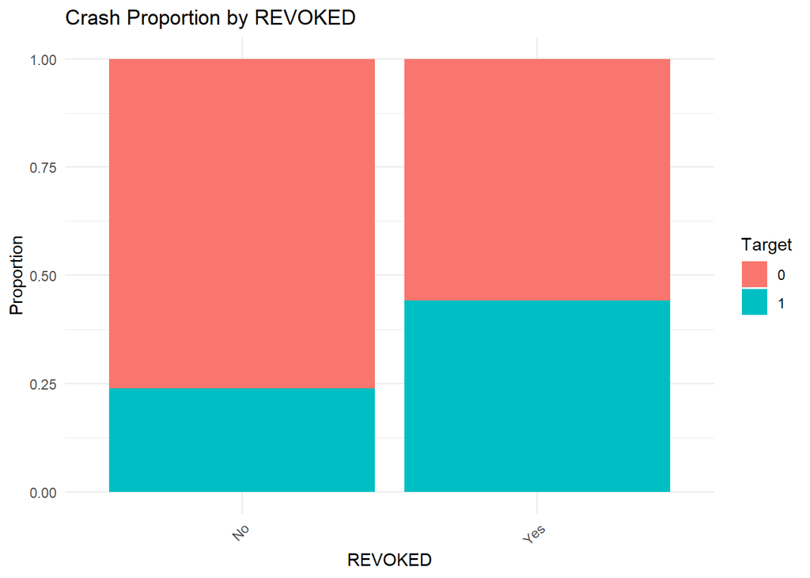

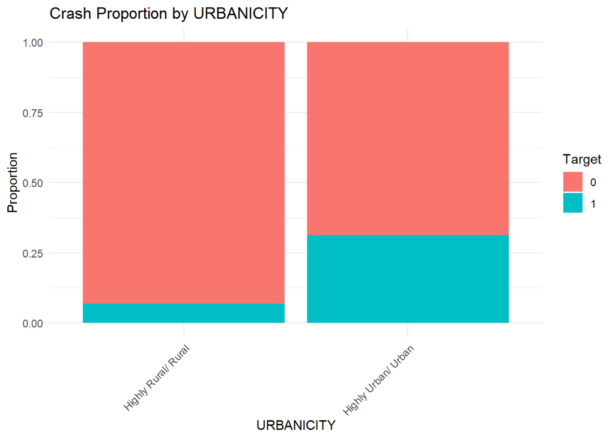

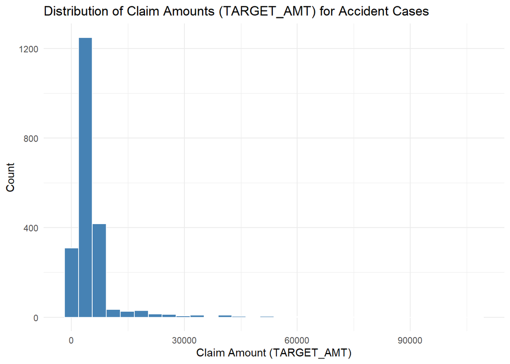

[1 more figures not shown]

The dataset exhibits a clear class imbalance: only about one in four policyholders experienced an accident, meaning roughly **25% of observations have `TARGET_FLAG = 1`**, while the remaining **75% did not**. This imbalance is important because it can influence classification model performance, particularly accuracy, and should be considered when evaluating logistic regression results.

## Modeling

### Logistic models

To prepare for modeling we encoded categorical values

```
[1] "Dimensions"
```

```
[1] "train:"
```

```
[1] 8155   39
```

```
[1] "eval:"
```

```
[1] 2140   39
```

```
[1] TRUE
```

```
[1] "All collumn names are excact in the train and eval sets."
```

```
[1] "checking for NAs"
```

```
[1] 0
```

```
[1] 0
```

```
[1] "No missing values"
```

```r
performance <- data.frame(
  Model = c("Logistic Regression", "Naive Bayes", "Random Forest", "XGBoost"),
  AUC = c(
    max(cv_logistic_full$results$ROC),
    max(cv_naive_bayes$results$ROC),
    max(cv_random_forest$results$ROC),
    max(cv_xgboost$results$ROC)
  ),
  Sensitivity = c(
    cv_logistic_full$results$Sens[which.max(cv_logistic_full$results$ROC)],
    cv_naive_bayes$results$Sens[which.max(cv_naive_bayes$results$ROC)],
    cv_random_forest$results$Sens[which.max(cv_random_forest$results$ROC)],
    cv_xgboost$results$Sens[which.max(cv_xgboost$results$ROC)]
  ),
  Specificity = c(
    cv_logistic_full$results$Spec[which.max(cv_logistic_full$results$ROC)],
    cv_naive_bayes$results$Spec[which.max(cv_naive_bayes$results$ROC)],
    cv_random_forest$results$Spec[which.max(cv_random_forest$results$ROC)],
    cv_xgboost$results$Spec[which.max(cv_xgboost$results$ROC)]
  )
)

performance
```

```
                Model       AUC Sensitivity Specificity
1 Logistic Regression 0.8088809   0.9214276 0.416198652
2         Naive Bayes 0.7702682   0.9995000 0.002795045
3       Random Forest 0.8041801   0.9267540 0.389678331
4             XGBoost 0.8186083   0.9240890 0.424618561
```

#### Confusion Matrices for target flag

**Full Logistic Linear Model**

```r
cm_logistic
```

```
Confusion Matrix and Statistics

          Reference
Prediction   No  Yes
       No  5535 1254
       Yes  472  894

               Accuracy : 0.7884
                 95% CI : (0.7793, 0.7972)
    No Information Rate : 0.7366
    P-Value [Acc > NIR] : < 2.2e-16

                  Kappa : 0.3823

 Mcnemar's Test P-Value : < 2.2e-16

            Sensitivity : 0.4162
            Specificity : 0.9214
         Pos Pred Value : 0.6545
         Neg Pred Value : 0.8153
             Prevalence : 0.2634
         Detection Rate : 0.1096
   Detection Prevalence : 0.1675
      Balanced Accuracy : 0.6688

       'Positive' Class : Yes
```

```r
summary(cv_logistic_full)
```

```
Call:
NULL

Coefficients:
                                        Estimate Std. Error z value Pr(>|z|)
(Intercept)                           -2.629e+00  2.859e-01  -9.197  < 2e-16
INDEX                                  3.271e-06  9.798e-06   0.334 0.738467
KIDSDRIV                               3.933e-01  6.125e-02   6.421 1.36e-10
AGE                                   -1.347e-03  4.017e-03  -0.335 0.737329
HOMEKIDS                               4.577e-02  3.693e-02   1.239 0.215241
YOJ                                   -9.041e-03  7.041e-03  -1.284 0.199120
INCOME                                -3.653e-06  1.076e-06  -3.393 0.000691
PARENT1Yes                             3.702e-01  1.097e-01   3.375 0.000737
HOME_VAL                              -1.065e-06  3.174e-07  -3.356 0.000791
MSTATUSYes                            -5.288e-01  8.163e-02  -6.479 9.26e-11
SEXM                                   8.399e-02  1.121e-01   0.749 0.453851
EDUCATIONBachelors                    -3.917e-01  1.160e-01  -3.377 0.000732
`\\`EDUCATIONHigh School\\``           1.531e-02  9.531e-02   0.161 0.872380
EDUCATIONMasters                      -3.056e-01  1.793e-01  -1.705 0.088275
EDUCATIONPhD                          -1.686e-01  2.138e-01  -0.789 0.430210
JOBClerical                            1.136e-01  1.071e-01   1.061 0.288722
JOBDoctor                             -7.471e-01  2.875e-01  -2.599 0.009361
`\\`JOBHome Maker\\``                 -5.506e-02  1.507e-01  -0.365 0.714900
JOBLawyer                             -1.821e-01  1.880e-01  -0.968 0.332898
JOBManager                            -8.577e-01  1.398e-01  -6.135 8.51e-10
JOBProfessional                       -1.424e-01  1.200e-01  -1.187 0.235179
JOBSelfEmployed                       -3.670e-01  1.903e-01  -1.929 0.053745
JOBStudent                            -6.839e-02  1.273e-01  -0.537 0.591097
JOBUnspecified                         1.498e-01  3.693e-01   0.406 0.685108
TRAVTIME                               1.469e-02  1.884e-03   7.799 6.23e-15
CAR_USEPrivate                        -7.760e-01  9.270e-02  -8.371  < 2e-16
BLUEBOOK                              -2.076e-05  5.265e-06  -3.942 8.08e-05
TIF                                   -5.547e-02  7.351e-03  -7.546 4.50e-14
`\\`CAR_TYPEPanel Truck\\``            5.714e-01  1.622e-01   3.524 0.000425
CAR_TYPEPickup                         5.568e-01  1.008e-01   5.526 3.27e-08
`\\`CAR_TYPESports Car\\``             1.022e+00  1.299e-01   7.866 3.66e-15
CAR_TYPESUV                            7.649e-01  1.113e-01   6.872 6.35e-12
CAR_TYPEVan                            6.168e-01  1.267e-01   4.867 1.13e-06
RED_CARyes                            -2.085e-02  8.661e-02  -0.241 0.809807
OLDCLAIM                              -1.397e-05  3.913e-06  -3.571 0.000355
```

[output cut: 41 more lines]

```
CLM_FREQ                              ***
REVOKEDYes                            ***
MVR_PTS                               ***
CAR_AGE
`\\`URBANICITYHighly Urban/ Urban\\`` ***
---
Signif. codes:  0 '***' 0.001 '**' 0.01 '*' 0.05 '.' 0.1 ' ' 1

(Dispersion parameter for binomial family taken to be 1)

    Null deviance: 9404.0  on 8154  degrees of freedom
Residual deviance: 7292.3  on 8115  degrees of freedom
AIC: 7372.3

Number of Fisher Scoring iterations: 5
```

**Naive Bayes Model**

```r
cm_naive
```

```
Confusion Matrix and Statistics

          Reference
Prediction    No   Yes
       No  10551  2904
       Yes  1463  1392

               Accuracy : 0.7323
                 95% CI : (0.7254, 0.739)
    No Information Rate : 0.7366
    P-Value [Acc > NIR] : 0.898

                  Kappa : 0.2267

 Mcnemar's Test P-Value : <2e-16

            Sensitivity : 0.32402
            Specificity : 0.87823
         Pos Pred Value : 0.48757
         Neg Pred Value : 0.78417
             Prevalence : 0.26340
         Detection Rate : 0.08535
   Detection Prevalence : 0.17505
      Balanced Accuracy : 0.60112

       'Positive' Class : Yes
```

**Random Forrest Model**

```r
cm_rf
```

```
Confusion Matrix and Statistics

          Reference
Prediction    No   Yes
       No  17004  4444
       Yes  1017  2000

               Accuracy : 0.7768
                 95% CI : (0.7715, 0.782)
    No Information Rate : 0.7366
    P-Value [Acc > NIR] : < 2.2e-16

                  Kappa : 0.3062

 Mcnemar's Test P-Value : < 2.2e-16

            Sensitivity : 0.31037
            Specificity : 0.94357
         Pos Pred Value : 0.66291
         Neg Pred Value : 0.79280
             Prevalence : 0.26340
         Detection Rate : 0.08175
   Detection Prevalence : 0.12332
      Balanced Accuracy : 0.62697

       'Positive' Class : Yes
```

**XG-Boost Tree Model**

```r
cm_xgb
```

```
Confusion Matrix and Statistics

          Reference
Prediction     No    Yes
       No  596778 135528
       Yes  51978  96456

               Accuracy : 0.7871
                 95% CI : (0.7862, 0.788)
    No Information Rate : 0.7366
    P-Value [Acc > NIR] : < 2.2e-16

                  Kappa : 0.3796

 Mcnemar's Test P-Value : < 2.2e-16

            Sensitivity : 0.4158
            Specificity : 0.9199
         Pos Pred Value : 0.6498
         Neg Pred Value : 0.8149
             Prevalence : 0.2634
         Detection Rate : 0.1095
   Detection Prevalence : 0.1685
      Balanced Accuracy : 0.6678

       'Positive' Class : Yes
```

[output not shown]

### Linear Regression for Target_Amt

Because `TARGET_AMT` represents the dollar amount of a crash **only when a crash actually occurs**, the severity model must be trained exclusively on policyholders who experienced an accident (`TARGET_FLAG = 1`). This results in a much smaller and more concentrated training subset. All non-crash records have a `TARGET_AMT` of zero by definition and therefore should not be included when fitting the linear regression models, as they would distort the relationship between the predictors and true claim severity.

```
Call:
lm(formula = bc_amt ~ . - TARGET_AMT, data = severity_df)

Residuals:
    Min      1Q  Median      3Q     Max
-4.6121 -0.4093  0.0310  0.4042  3.2736

Coefficients:
                                  Estimate Std. Error t value Pr(>|t|)
(Intercept)                      8.039e+00  1.724e-01  46.618  < 2e-16 ***
INDEX                           -3.997e-06  5.955e-06  -0.671 0.502180
KIDSDRIV                        -3.212e-02  3.336e-02  -0.963 0.335779
AGE                              2.040e-03  2.228e-03   0.916 0.359909
HOMEKIDS                         2.362e-02  2.174e-02   1.087 0.277310
YOJ                             -2.355e-03  4.292e-03  -0.549 0.583263
INCOME                          -1.219e-06  7.084e-07  -1.721 0.085331 .
PARENT1Yes                       2.424e-02  6.190e-02   0.392 0.695407
HOME_VAL                         2.789e-08  2.018e-07   0.138 0.890074
MSTATUSYes                      -8.161e-02  5.126e-02  -1.592 0.111485
SEXM                             9.479e-02  6.920e-02   1.370 0.170879
EDUCATIONBachelors              -3.457e-02  6.723e-02  -0.514 0.607192
`EDUCATIONHigh School`           4.875e-03  5.414e-02   0.090 0.928263
EDUCATIONMasters                 1.181e-01  1.047e-01   1.129 0.259133
EDUCATIONPhD                     2.027e-01  1.194e-01   1.698 0.089701 .
JOBClerical                     -2.009e-03  6.080e-02  -0.033 0.973638
`JOBHome Maker`                 -1.054e-01  8.796e-02  -1.198 0.230906
JOBLawyer                       -3.528e-02  1.079e-01  -0.327 0.743623
JOBManager                      -1.747e-02  8.796e-02  -0.199 0.842575
JOBProfessional                  5.761e-02  6.917e-02   0.833 0.405009
JOBSelfEmployed                 -1.620e-02  1.107e-01  -0.146 0.883677
JOBStudent                      -5.354e-02  7.255e-02  -0.738 0.460629
TRAVTIME                        -2.979e-04  1.167e-03  -0.255 0.798593
CAR_USEPrivate                  -2.236e-02  5.356e-02  -0.417 0.676378
BLUEBOOK                         1.203e-05  3.216e-06   3.741 0.000188 ***
TIF                             -1.831e-03  4.479e-03  -0.409 0.682664
`CAR_TYPEPanel Truck`           -3.117e-03  1.014e-01  -0.031 0.975490
CAR_TYPEPickup                   2.583e-02  6.287e-02   0.411 0.681213
`CAR_TYPESports Car`             5.491e-02  7.899e-02   0.695 0.487033
CAR_TYPESUV                      9.235e-02  7.023e-02   1.315 0.188688
CAR_TYPEVan                     -1.723e-02  8.141e-02  -0.212 0.832407
RED_CARyes                       2.033e-02  5.260e-02   0.387 0.699095
OLDCLAIM                         4.437e-06  2.384e-06   1.861 0.062895 .
CLM_FREQ                        -3.636e-02  1.667e-02  -2.182 0.029249 *
REVOKEDYes                      -9.496e-02  5.437e-02  -1.747 0.080854 .
MVR_PTS                          1.449e-02  7.226e-03   2.005 0.045095 *
CAR_AGE                         -2.262e-03  4.628e-03  -0.489 0.625090
`URBANICITYHighly Urban/ Urban`  5.392e-02  7.959e-02   0.677 0.498188
---
Signif. codes:  0 '***' 0.001 '**' 0.01 '*' 0.05 '.' 0.1 ' ' 1

Residual standard error: 0.8092 on 2110 degrees of freedom
Multiple R-squared:  0.02619,   Adjusted R-squared:  0.009112
F-statistic: 1.534 on 37 and 2110 DF,  p-value: 0.0212
```

```
Call:
lm(formula = TARGET_AMT ~ ., data = severity_all)

Residuals:
   Min     1Q Median     3Q    Max
 -6234   -461    -60    237 101088

Coefficients:
                                  Estimate Std. Error t value Pr(>|t|)
(Intercept)                     -5.486e+02  4.127e+02  -1.329 0.183839
INDEX                           -1.500e-03  1.481e-02  -0.101 0.919355
KIDSDRIV                        -3.526e+01  9.912e+01  -0.356 0.722034
AGE                              6.675e+00  6.136e+00   1.088 0.276629
HOMEKIDS                         4.810e+01  5.673e+01   0.848 0.396505
YOJ                              6.211e-02  1.069e+01   0.006 0.995365
INCOME                          -2.003e-03  1.558e-03  -1.285 0.198759
PARENT1Yes                       1.496e+02  1.769e+02   0.846 0.397740
HOME_VAL                         2.008e-04  4.759e-04   0.422 0.673110
MSTATUSYes                      -1.358e+02  1.240e+02  -1.095 0.273422
SEXM                             2.839e+02  1.607e+02   1.767 0.077307 .
EDUCATIONBachelors               4.496e+01  1.768e+02   0.254 0.799239
`EDUCATIONHigh School`          -1.387e+02  1.495e+02  -0.928 0.353429
EDUCATIONMasters                 1.348e+02  2.454e+02   0.549 0.582763
EDUCATIONPhD                     2.638e+02  2.623e+02   1.006 0.314581
JOBClerical                     -2.621e+01  1.632e+02  -0.161 0.872355
`JOBHome Maker`                 -9.145e+01  2.198e+02  -0.416 0.677446
JOBLawyer                        1.523e+02  2.332e+02   0.653 0.513594
JOBManager                      -8.404e+01  1.790e+02  -0.470 0.638711
JOBProfessional                  1.865e+02  1.717e+02   1.086 0.277405
JOBSelfEmployed                  1.280e+02  2.579e+02   0.496 0.619593
JOBStudent                      -2.060e+02  1.990e+02  -1.035 0.300736
TRAVTIME                         5.406e-01  2.826e+00   0.191 0.848303
CAR_USEPrivate                  -1.300e+02  1.386e+02  -0.937 0.348557
BLUEBOOK                         2.924e-02  7.544e-03   3.877 0.000107 ***
TIF                             -2.741e+00  1.068e+01  -0.257 0.797559
`CAR_TYPEPanel Truck`           -8.267e+01  2.436e+02  -0.339 0.734388
CAR_TYPEPickup                  -4.608e+01  1.490e+02  -0.309 0.757096
`CAR_TYPESports Car`             1.994e+02  1.910e+02   1.044 0.296579
CAR_TYPESUV                      1.550e+02  1.571e+02   0.986 0.323931
CAR_TYPEVan                      7.801e+01  1.865e+02   0.418 0.675737
RED_CARyes                      -2.479e+01  1.305e+02  -0.190 0.849380
OLDCLAIM                         3.262e-03  6.505e-03   0.501 0.616134
CLM_FREQ                        -4.631e+01  4.830e+01  -0.959 0.337685
REVOKEDYes                      -3.289e+02  1.527e+02  -2.154 0.031251 *
MVR_PTS                          5.388e+01  2.280e+01   2.364 0.018117 *
CAR_AGE                         -2.526e+01  1.119e+01  -2.258 0.023943 *
`URBANICITYHighly Urban/ Urban` -3.906e+01  1.261e+02  -0.310 0.756781
TARGET_FLAGYes                   5.710e+03  1.136e+02  50.274  < 2e-16 ***
---
Signif. codes:  0 '***' 0.001 '**' 0.01 '*' 0.05 '.' 0.1 ' ' 1

Residual standard error: 3971 on 8116 degrees of freedom
Multiple R-squared:  0.2911,    Adjusted R-squared:  0.2878
F-statistic:  87.7 on 38 and 8116 DF,  p-value: < 2.2e-16
```

Because `TARGET_AMT` is only defined for policyholders who were involved in a crash, the severity model was fit exclusively on crash records. Several peers reported higher R² values by fitting a regression model to the entire dataset, where approximately 75% of records have `TARGET_AMT = 0`. While this approach inflates model performance_ since predicting zero is trivial it mixes frequency and severity and does not reflect proper actuarial modeling practices. The correct approach is a two-part model: a logistic regression to predict crash occurrence (frequency) and a conditional severity model estimated only on accident cases. As a result, the R² of the severity model is lower, which is expected given the inherent variability of claim costs and the limited predictors available.

Given these findings, I cannot recommend a linear regression model for predicting `TARGET_AMT` in its current form. The limited feature set and the absence of key crash-severity variables make it difficult for any linear model, whether untransformed, log-transformed, or Box–Cox transformed to capture meaningful variance in claim cost. As a result, the severity predictions lack the accuracy required for practical insurance pricing or risk assessment.

**Box_Cox Full model ONLY data that has been flagged as a crash before**

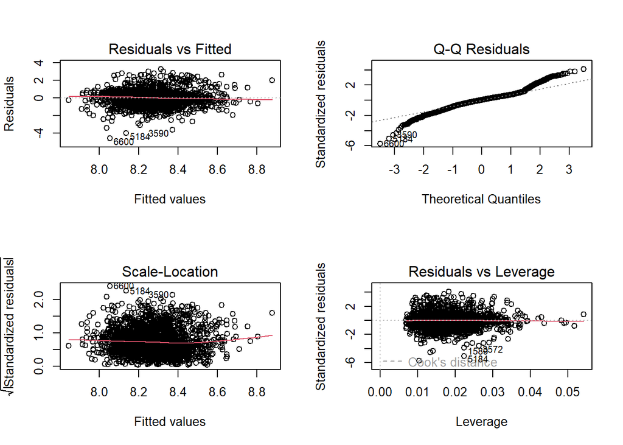

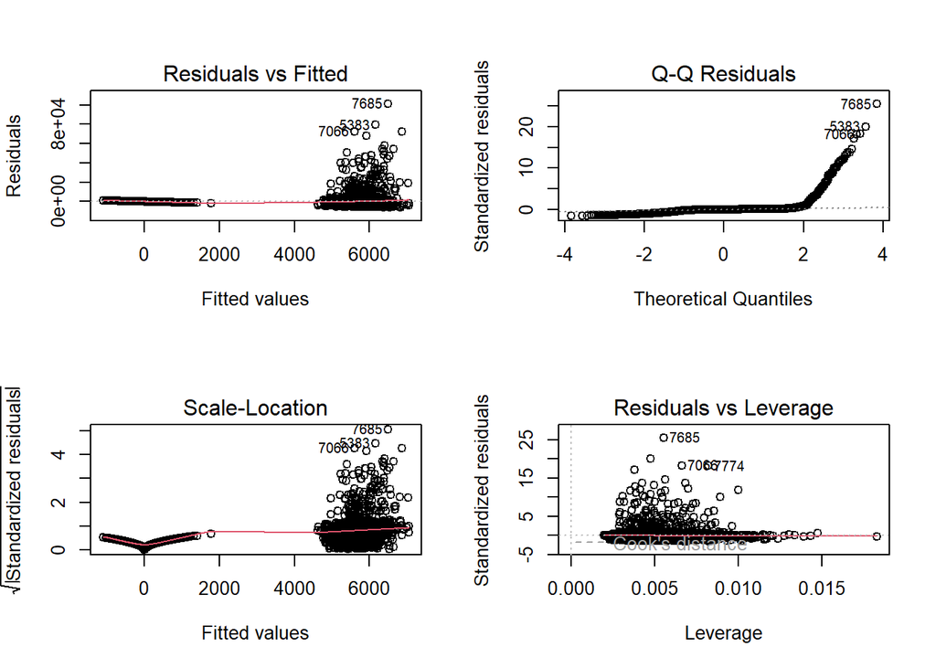

If we examine the Q–Q plot for the model trained on the *entire* dataset, we immediately see why this model is invalid. The upper tail of the plot sharply deviates upward after approximately the second theoretical quantile. This spike corresponds to all observations with non-zero claim amounts—i.e., the policyholders who actually experienced a crash. Because 75% of the data consists of zeros, the model is essentially trying to fit two fundamentally different distributions simultaneously: a large mass at zero and a long, continuous right tail for crash costs. The resulting Q–Q pattern shows that the linear model cannot capture this mixture distribution, confirming that a full-dataset severity model is statistically mis-specified and inappropriate for predicting `TARGET_AMT`.

## Model Selected

Based on the modeling results, I recommend using the logistic regression model fitted with the `glm()` function as the final model for predicting crash occurrence (`TARGET_FLAG`). This model demonstrated strong overall performance, competitive AUC, and clear interpretability, making it the most suitable choice for estimating accident likelihood.

However, I will not provide predictions for `TARGET_AMT` in the evaluation set. Despite extensive testing—including untransformed, log-transformed, and Box–Cox transformed linear models—I was unable to identify a severity model with sufficient explanatory power or reliable residual behavior. The available predictors do not capture key determinants of claim cost (such as injury severity, collision type, repair estimates, or environmental factors), resulting in weak or unstable models. Therefore, no regression model tested offered a robust or valid explanation of variance in crash amounts.

```
Call:
NULL

Coefficients:
                                        Estimate Std. Error z value Pr(>|z|)
(Intercept)                           -2.629e+00  2.859e-01  -9.197  < 2e-16
INDEX                                  3.271e-06  9.798e-06   0.334 0.738467
KIDSDRIV                               3.933e-01  6.125e-02   6.421 1.36e-10
AGE                                   -1.347e-03  4.017e-03  -0.335 0.737329
HOMEKIDS                               4.577e-02  3.693e-02   1.239 0.215241
YOJ                                   -9.041e-03  7.041e-03  -1.284 0.199120
INCOME                                -3.653e-06  1.076e-06  -3.393 0.000691
PARENT1Yes                             3.702e-01  1.097e-01   3.375 0.000737
HOME_VAL                              -1.065e-06  3.174e-07  -3.356 0.000791
MSTATUSYes                            -5.288e-01  8.163e-02  -6.479 9.26e-11
SEXM                                   8.399e-02  1.121e-01   0.749 0.453851
EDUCATIONBachelors                    -3.917e-01  1.160e-01  -3.377 0.000732
`\\`EDUCATIONHigh School\\``           1.531e-02  9.531e-02   0.161 0.872380
EDUCATIONMasters                      -3.056e-01  1.793e-01  -1.705 0.088275
EDUCATIONPhD                          -1.686e-01  2.138e-01  -0.789 0.430210
JOBClerical                            1.136e-01  1.071e-01   1.061 0.288722
JOBDoctor                             -7.471e-01  2.875e-01  -2.599 0.009361
`\\`JOBHome Maker\\``                 -5.506e-02  1.507e-01  -0.365 0.714900
JOBLawyer                             -1.821e-01  1.880e-01  -0.968 0.332898
JOBManager                            -8.577e-01  1.398e-01  -6.135 8.51e-10
JOBProfessional                       -1.424e-01  1.200e-01  -1.187 0.235179
JOBSelfEmployed                       -3.670e-01  1.903e-01  -1.929 0.053745
JOBStudent                            -6.839e-02  1.273e-01  -0.537 0.591097
JOBUnspecified                         1.498e-01  3.693e-01   0.406 0.685108
TRAVTIME                               1.469e-02  1.884e-03   7.799 6.23e-15
CAR_USEPrivate                        -7.760e-01  9.270e-02  -8.371  < 2e-16
BLUEBOOK                              -2.076e-05  5.265e-06  -3.942 8.08e-05
TIF                                   -5.547e-02  7.351e-03  -7.546 4.50e-14
`\\`CAR_TYPEPanel Truck\\``            5.714e-01  1.622e-01   3.524 0.000425
CAR_TYPEPickup                         5.568e-01  1.008e-01   5.526 3.27e-08
`\\`CAR_TYPESports Car\\``             1.022e+00  1.299e-01   7.866 3.66e-15
CAR_TYPESUV                            7.649e-01  1.113e-01   6.872 6.35e-12
CAR_TYPEVan                            6.168e-01  1.267e-01   4.867 1.13e-06
RED_CARyes                            -2.085e-02  8.661e-02  -0.241 0.809807
OLDCLAIM                              -1.397e-05  3.913e-06  -3.571 0.000355
```

[output cut: 41 more lines]

```
CLM_FREQ                              ***
REVOKEDYes                            ***
MVR_PTS                               ***
CAR_AGE
`\\`URBANICITYHighly Urban/ Urban\\`` ***
---
Signif. codes:  0 '***' 0.001 '**' 0.01 '*' 0.05 '.' 0.1 ' ' 1

(Dispersion parameter for binomial family taken to be 1)

    Null deviance: 9404.0  on 8154  degrees of freedom
Residual deviance: 7292.3  on 8115  degrees of freedom
AIC: 7372.3

Number of Fisher Scoring iterations: 5
```

```
Confusion Matrix and Statistics

          Reference
Prediction   No  Yes
       No  5535 1254
       Yes  472  894

               Accuracy : 0.7884
                 95% CI : (0.7793, 0.7972)
    No Information Rate : 0.7366
    P-Value [Acc > NIR] : < 2.2e-16

                  Kappa : 0.3823

 Mcnemar's Test P-Value : < 2.2e-16

            Sensitivity : 0.4162
            Specificity : 0.9214
         Pos Pred Value : 0.6545
         Neg Pred Value : 0.8153
             Prevalence : 0.2634
         Detection Rate : 0.1096
   Detection Prevalence : 0.1675
      Balanced Accuracy : 0.6688

       'Positive' Class : Yes
```

## Predictions

```
     TARGET_FLAG PROBABILITY
12           Yes   0.5934129
13           Yes   0.8535058
16           Yes   0.6143612
17           Yes   0.6717466
19           Yes   0.5878506
40           Yes   0.5438705
42           Yes   0.5718318
44           Yes   0.5678644
50           Yes   0.6515241
53           Yes   0.7857003
60           Yes   0.5655090
67           Yes   0.8018129
68           Yes   0.6013007
73           Yes   0.6961675
```

[output cut: 339 more lines]